# ms_7

Will Schrepferman

4/6/2020

## Question 1

1A) Here is the output:

Data summary

[output not shown]

**Variable type: numeric**

| skim_variable | n_missing | complete_rate | mean | sd | p0 | p25 | p50 | p75 | p100 | hist |
| --- | --- | --- | --- | --- | --- | --- | --- | --- | --- | --- |
| nominate_percentile | 0 | 1 | 49.95 | 28.95 | 0 | 24.81 | 50 | 75 | 100 | ▇▇▇▇▇ |
| age | 0 | 1 | 58.91 | 11.78 | 30 | 50.00 | 59 | 68 | 86 | ▂▅▇▇▂ |

1B)

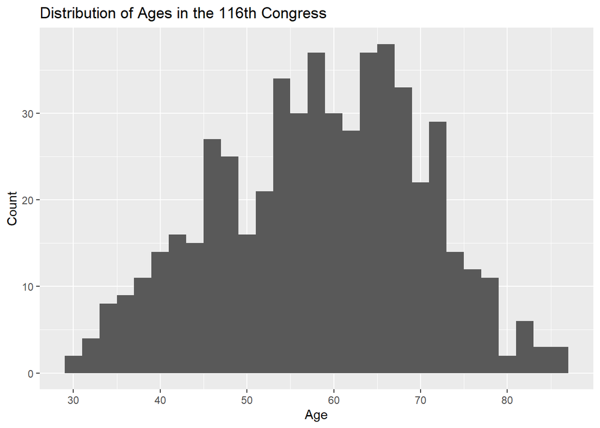

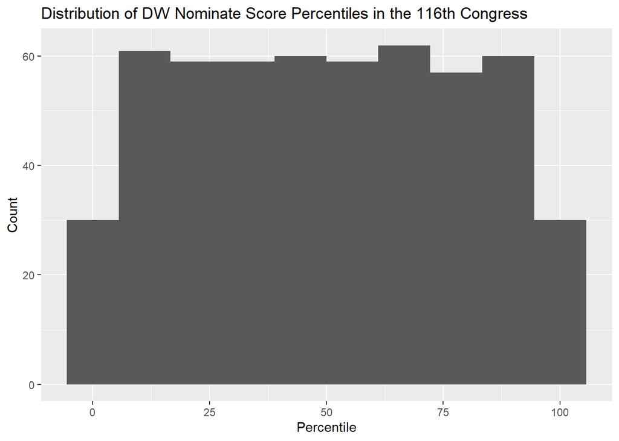

1D)

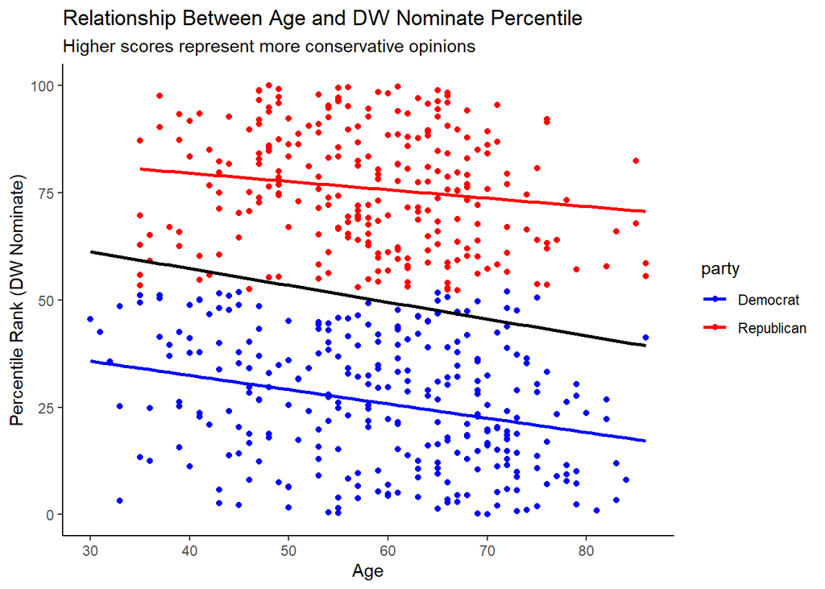

## Question 2

2A)

Effect of Age on DW Nominate Percentile

[output not shown]

2B) The estimated average treatment effect of age is a decrease of 0.33 in the percentile of a member’s DW Nominate score per every year they are older. This should not be treated as causal, as other variables that are not age could play a role; for example, older Democratic Congresspeople could be concentrated in more liberal states. Calculating a confidence interval around the average treatment effect gives us an idea of the range that both the intercept and correlation coeffecient of the two variables’ regression could fall into.

2C) Under the Rubin Causal Model in this example, the potential outcomes are the DW nominate score when treated with military service and not. The coeffecient of military should be interpreted as the average treatment effect, or the average impact on DW nominate score percentile from the presence of treatment. The ATE can be used to estimate the missing outcomes in order to measure the difference in potential outcomes. The presence of randomization in assignment means this analysis could be considered causal, but we have to be wary of potential confounding variables.

## Question 3

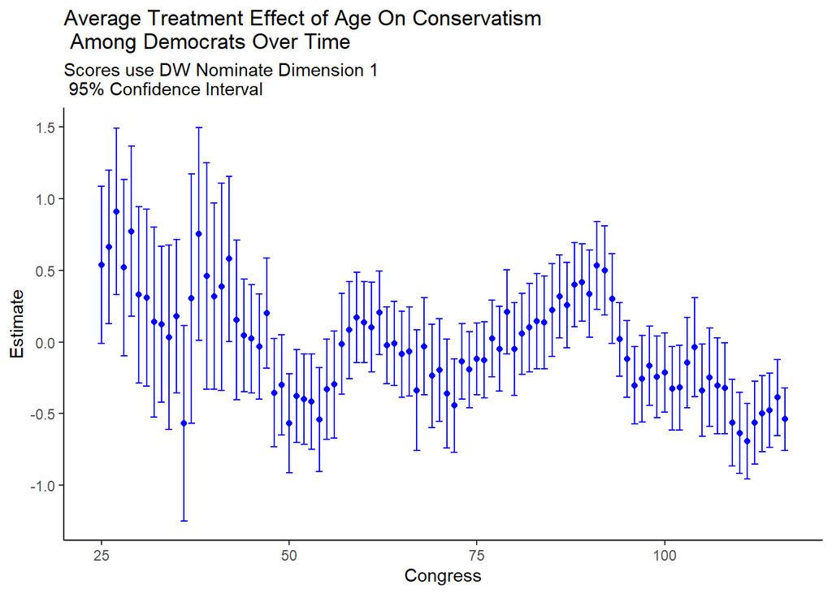